# Mushroom Classification

Hitaishi Bairapureddy

2024-04-16

## Summary of Analysis

- The analysis explored how well K-Nearest Neighbors (KNN) and Naive Bayes algorithms can classify mushrooms.
- Data Preparation -The mushroom data was first checked for missing values, and a technique called KNN imputation was used to fill in any missing data points.
- Exploratory Data Analysis -To understand the data better, various visualizations were created, including boxplots, histograms, and frequency tables.
- Feature Selection- To identify the most important features for classification, the analysis involved looking at anova tables, correlations between features and using a technique called Principal Component Analysis (PCA). Based on PCA biplot, 8 features were selected
- Predictive analytics -We built a classification model using both KNN and Naive Bayes algorithms. Interestingly, KNN achieved maximum accuracy for all k values tested and naive bayes achieved less accuracy when compared to the K-NN
- Evaluating the model -To ensure this wasn’t due to overfitting, the models were evaluated using cross validation, and it appears the high accuracy is genuine.ROC curves were plotted and K-NN model has more area under curve.

### Loading and Importing the Data

```r
library(readr)
```

```r
mdata <- read.csv("C:\\Users\\bhita\\OneDrive\\Documents\\hithu\\mushroom.csv" , na.strings = c("", " "))
head(mdata)
```

```
##   class cap.diameter cap.shape cap.surface cap.color does.bruise.or.bleed
## 1     p        15.26         x           g         o                    f
## 2     p        16.60         x           g         o                    f
## 3     p        14.07         x           g         o                    f
## 4     p        14.17         f           h         e                    f
## 5     p        14.64         x           h         o                    f
## 6     p        15.34         x           g         o                    f
##   gill.attachment gill.spacing gill.color stem.height stem.width stem.root
## 1               e         <NA>          w       16.95      17.09         s
## 2               e         <NA>          w       17.99      18.19         s
## 3               e         <NA>          w       17.80      17.74         s
## 4               e         <NA>          w       15.77      15.98         s
## 5               e         <NA>          w       16.53      17.20         s
## 6               e         <NA>          w       17.84      18.79         s
##   stem.surface stem.color veil.type veil.color has.ring ring.type
## 1            y          w         u          w        t         g
## 2            y          w         u          w        t         g
## 3            y          w         u          w        t         g
## 4            y          w         u          w        t         p
## 5            y          w         u          w        t         p
## 6            y          w         u          w        t         p
##   spore.print.color habitat season
## 1              <NA>       d      w
## 2              <NA>       d      u
## 3              <NA>       d      w
## 4              <NA>       d      w
## 5              <NA>       d      w
## 6              <NA>       d      u
```

### Loading Required Packages

```r
library(tidyverse)     # Data manipulation and visualization
library(VIM)           # Visualization and Imputation of Missing values
library(caret)         # General ML tasks
```

```r
library(corrplot)      # Visualization of correlation matrix
library(FactoMineR)    # PCA
library(factoextra)    # PCA visualization
library(class)         # kNN classifier
```

## Exploratory Data Analysis

```r
library(dplyr)
summary(mdata)
```

```
##     class            cap.diameter     cap.shape         cap.surface
##  Length:61069       Min.   : 0.380   Length:61069       Length:61069
##  Class :character   1st Qu.: 3.480   Class :character   Class :character
##  Mode  :character   Median : 5.860   Mode  :character   Mode  :character
##                     Mean   : 6.734
##                     3rd Qu.: 8.540
##                     Max.   :62.340
##   cap.color         does.bruise.or.bleed gill.attachment    gill.spacing
##  Length:61069       Length:61069         Length:61069       Length:61069
##  Class :character   Class :character     Class :character   Class :character
##  Mode  :character   Mode  :character     Mode  :character   Mode  :character
##
##
##
##   gill.color         stem.height       stem.width      stem.root
##  Length:61069       Min.   : 0.000   Min.   :  0.00   Length:61069
##  Class :character   1st Qu.: 4.640   1st Qu.:  5.21   Class :character
##  Mode  :character   Median : 5.950   Median : 10.19   Mode  :character
##                     Mean   : 6.582   Mean   : 12.15
##                     3rd Qu.: 7.740   3rd Qu.: 16.57
##                     Max.   :33.920   Max.   :103.91
##  stem.surface        stem.color         veil.type          veil.color
##  Length:61069       Length:61069       Length:61069       Length:61069
##  Class :character   Class :character   Class :character   Class :character
##  Mode  :character   Mode  :character   Mode  :character   Mode  :character
##
##
##
##    has.ring          ring.type         spore.print.color    habitat
##  Length:61069       Length:61069       Length:61069       Length:61069
##  Class :character   Class :character   Class :character   Class :character
##  Mode  :character   Mode  :character   Mode  :character   Mode  :character
##
##
##
##     season
##  Length:61069
##  Class :character
##  Mode  :character
##
##
##
```

### Converting Categorical Variables to Numerical variables

```r
#Converting categorical variables to numericals except for the Response which is "Class"
data_x <- data.frame(sapply(mdata[1:21], function (x) as.numeric(as.factor(x))))
mdata <- data.frame(data_x, class = mdata$class)
```

```r
summary(mdata)
```

```
##      class        cap.diameter      cap.shape      cap.surface
##  Min.   :1.000   Min.   :   1.0   Min.   :1.000   Min.   : 1.000
##  1st Qu.:1.000   1st Qu.: 304.0   1st Qu.:3.000   1st Qu.: 3.000
##  Median :2.000   Median : 542.0   Median :6.000   Median : 8.000
##  Mean   :1.555   Mean   : 613.6   Mean   :5.042   Mean   : 6.483
##  3rd Qu.:2.000   3rd Qu.: 810.0   3rd Qu.:7.000   3rd Qu.: 9.000
##  Max.   :2.000   Max.   :2571.0   Max.   :7.000   Max.   :11.000
##                                                   NA's   :14120
##    cap.color      does.bruise.or.bleed gill.attachment  gill.spacing
##  Min.   : 1.000   Min.   :1.000        Min.   :1.000   Min.   :1.000
##  1st Qu.: 6.000   1st Qu.:1.000        1st Qu.:2.000   1st Qu.:1.000
##  Median : 6.000   Median :1.000        Median :3.000   Median :1.000
##  Mean   : 7.145   Mean   :1.173        Mean   :3.517   Mean   :1.412
##  3rd Qu.:11.000   3rd Qu.:1.000        3rd Qu.:6.000   3rd Qu.:2.000
##  Max.   :12.000   Max.   :2.000        Max.   :7.000   Max.   :3.000
##                                        NA's   :9884    NA's   :25063
##    gill.color      stem.height       stem.width     stem.root
##  Min.   : 1.000   Min.   :   1.0   Min.   :   1   Min.   :1.00
##  1st Qu.: 6.000   1st Qu.: 355.0   1st Qu.: 469   1st Qu.:1.00
##  Median : 8.000   Median : 486.0   Median : 967   Median :3.00
##  Mean   : 8.339   Mean   : 548.5   Mean   :1140   Mean   :3.07
##  3rd Qu.:11.000   3rd Qu.: 665.0   3rd Qu.:1605   3rd Qu.:5.00
##  Max.   :12.000   Max.   :2226.0   Max.   :4630   Max.   :5.00
##                                                   NA's   :51538
##   stem.surface     stem.color       veil.type       veil.color
##  Min.   :1.00    Min.   : 1.000   Min.   :1       Min.   :1.00
##  1st Qu.:4.00    1st Qu.: 7.000   1st Qu.:1       1st Qu.:5.00
##  Median :6.00    Median :12.000   Median :1       Median :5.00
##  Mean   :5.49    Mean   : 9.429   Mean   :1       Mean   :4.64
##  3rd Qu.:7.00    3rd Qu.:12.000   3rd Qu.:1       3rd Qu.:5.00
##  Max.   :8.00    Max.   :13.000   Max.   :1       Max.   :6.00
##  NA's   :38124                    NA's   :57892   NA's   :53656
##     has.ring       ring.type     spore.print.color    habitat
##  Min.   :1.000   Min.   :1.000   Min.   :1.00      Min.   :1.000
##  1st Qu.:1.000   1st Qu.:2.000   1st Qu.:2.00      1st Qu.:1.000
##  Median :1.000   Median :2.000   Median :3.00      Median :1.000
##  Mean   :1.249   Mean   :2.469   Mean   :3.66      Mean   :1.624
##  3rd Qu.:1.000   3rd Qu.:2.000   3rd Qu.:4.00      3rd Qu.:2.000
##  Max.   :2.000   Max.   :8.000   Max.   :7.00      Max.   :8.000
##                  NA's   :2471    NA's   :54715
##      season        class.1
##  Min.   :1.000   Length:61069
##  1st Qu.:1.000   Class :character
##  Median :2.000   Mode  :character
##  Mean   :2.053
##  3rd Qu.:3.000
##  Max.   :4.000
##
```

### Checking for the Missing values in the dataset

```r
missing.values <- sum(is.na(mdata))
if(missing.values > 0) {
  print("There are missing values in the dataset provided.")
} else{
  print("There are no missing values in the dataset provided.")
}
```

```
## [1] "There are missing values in the dataset provided."
```

```r
#Counting missing values in each variable
missing_counts <- colSums(is.na(mdata))
print("\nNumber of missing values in each variable:")
```

```
## [1] "\nNumber of missing values in each variable:"
```

```r
print(missing_counts)
```

```
##                class         cap.diameter            cap.shape
##                    0                    0                    0
##          cap.surface            cap.color does.bruise.or.bleed
##                14120                    0                    0
##      gill.attachment         gill.spacing           gill.color
##                 9884                25063                    0
##          stem.height           stem.width            stem.root
##                    0                    0                51538
##         stem.surface           stem.color            veil.type
##                38124                    0                57892
##           veil.color             has.ring            ring.type
##                53656                    0                 2471
##    spore.print.color              habitat               season
##                54715                    0                    0
##              class.1
##                    0
```

```r
# Identifying complete cases
complete_cases <- complete.cases(mdata)

# Counting complete cases
total_complete_cases <- sum(complete_cases)

# Printing the count of CC
cat("Total complete cases:", total_complete_cases, "\n")
```

```
## Total complete cases: 0
```

```r
class(mdata)
```

```
## [1] "data.frame"
```

### Missing Value Imputation with kNN

```r
# Loading the library
library(VIM)
missed.imputed <- kNN(mdata, variable=c("cap.surface", "gill.attachment", "gill.spacing", "stem.root", "stem.surface", "veil.color", "veil.type", "ring.type", "spore.print.color"), k=4)
colMeans(is.na(missed.imputed))
```

```
##                 class          cap.diameter             cap.shape
##                     0                     0                     0
##           cap.surface             cap.color  does.bruise.or.bleed
##                     0                     0                     0
##       gill.attachment          gill.spacing            gill.color
##                     0                     0                     0
##           stem.height            stem.width             stem.root
##                     0                     0                     0
##          stem.surface            stem.color             veil.type
##                     0                     0                     0
##            veil.color              has.ring             ring.type
##                     0                     0                     0
##     spore.print.color               habitat                season
##                     0                     0                     0
##               class.1       cap.surface_imp   gill.attachment_imp
##                     0                     0                     0
##      gill.spacing_imp         stem.root_imp      stem.surface_imp
##                     0                     0                     0
##        veil.color_imp         veil.type_imp         ring.type_imp
##                     0                     0                     0
## spore.print.color_imp
##                     0
```

### Descriptive Statistics

```r
summary(missed.imputed)
```

```
##      class        cap.diameter      cap.shape      cap.surface
##  Min.   :1.000   Min.   :   1.0   Min.   :1.000   Min.   : 1.00
##  1st Qu.:1.000   1st Qu.: 304.0   1st Qu.:3.000   1st Qu.: 4.00
##  Median :2.000   Median : 542.0   Median :6.000   Median : 8.00
##  Mean   :1.555   Mean   : 613.6   Mean   :5.042   Mean   : 6.49
##  3rd Qu.:2.000   3rd Qu.: 810.0   3rd Qu.:7.000   3rd Qu.: 9.00
##  Max.   :2.000   Max.   :2571.0   Max.   :7.000   Max.   :11.00
##    cap.color      does.bruise.or.bleed gill.attachment  gill.spacing
##  Min.   : 1.000   Min.   :1.000        Min.   :1.000   Min.   :1.000
##  1st Qu.: 6.000   1st Qu.:1.000        1st Qu.:2.000   1st Qu.:1.000
##  Median : 6.000   Median :1.000        Median :3.000   Median :1.000
##  Mean   : 7.145   Mean   :1.173        Mean   :3.593   Mean   :1.338
##  3rd Qu.:11.000   3rd Qu.:1.000        3rd Qu.:6.000   3rd Qu.:2.000
##  Max.   :12.000   Max.   :2.000        Max.   :7.000   Max.   :3.000
##    gill.color      stem.height       stem.width     stem.root
##  Min.   : 1.000   Min.   :   1.0   Min.   :   1   Min.   :1.000
##  1st Qu.: 6.000   1st Qu.: 355.0   1st Qu.: 469   1st Qu.:1.000
##  Median : 8.000   Median : 486.0   Median : 967   Median :2.000
##  Mean   : 8.339   Mean   : 548.5   Mean   :1140   Mean   :2.605
##  3rd Qu.:11.000   3rd Qu.: 665.0   3rd Qu.:1605   3rd Qu.:5.000
##  Max.   :12.000   Max.   :2226.0   Max.   :4630   Max.   :5.000
##   stem.surface    stem.color       veil.type   veil.color       has.ring
##  Min.   :1.00   Min.   : 1.000   Min.   :1   Min.   :1.000   Min.   :1.000
##  1st Qu.:5.00   1st Qu.: 7.000   1st Qu.:1   1st Qu.:3.000   1st Qu.:1.000
##  Median :6.00   Median :12.000   Median :1   Median :5.000   Median :1.000
##  Mean   :5.91   Mean   : 9.429   Mean   :1   Mean   :4.099   Mean   :1.249
##  3rd Qu.:7.00   3rd Qu.:12.000   3rd Qu.:1   3rd Qu.:5.000   3rd Qu.:1.000
##  Max.   :8.00   Max.   :13.000   Max.   :1   Max.   :6.000   Max.   :2.000
##    ring.type     spore.print.color    habitat          season
##  Min.   :1.000   Min.   :1.000     Min.   :1.000   Min.   :1.000
##  1st Qu.:2.000   1st Qu.:3.000     1st Qu.:1.000   1st Qu.:1.000
##  Median :2.000   Median :4.000     Median :1.000   Median :2.000
##  Mean   :2.578   Mean   :4.423     Mean   :1.624   Mean   :2.053
##  3rd Qu.:2.000   3rd Qu.:7.000     3rd Qu.:2.000   3rd Qu.:3.000
##  Max.   :8.000   Max.   :7.000     Max.   :8.000   Max.   :4.000
##    class.1          cap.surface_imp gill.attachment_imp gill.spacing_imp
##  Length:61069       Mode :logical   Mode :logical       Mode :logical
##  Class :character   FALSE:46949     FALSE:51185         FALSE:36006
##  Mode  :character   TRUE :14120     TRUE :9884          TRUE :25063
##
##
##
##  stem.root_imp   stem.surface_imp veil.color_imp  veil.type_imp
##  Mode :logical   Mode :logical    Mode :logical   Mode :logical
##  FALSE:9531      FALSE:22945      FALSE:7413      FALSE:3177
##  TRUE :51538     TRUE :38124      TRUE :53656     TRUE :57892
##
##
##
##  ring.type_imp   spore.print.color_imp
##  Mode :logical   Mode :logical
##  FALSE:58598     FALSE:6354
##  TRUE :2471      TRUE :54715
##
##
##
```

```r
#Removing indicator variables as it would cluster and complex the further analysis
colnames(missed.imputed)
```

```
##  [1] "class"                 "cap.diameter"          "cap.shape"
##  [4] "cap.surface"           "cap.color"             "does.bruise.or.bleed"
##  [7] "gill.attachment"       "gill.spacing"          "gill.color"
## [10] "stem.height"           "stem.width"            "stem.root"
## [13] "stem.surface"          "stem.color"            "veil.type"
## [16] "veil.color"            "has.ring"              "ring.type"
## [19] "spore.print.color"     "habitat"               "season"
## [22] "class.1"               "cap.surface_imp"       "gill.attachment_imp"
## [25] "gill.spacing_imp"      "stem.root_imp"         "stem.surface_imp"
## [28] "veil.color_imp"        "veil.type_imp"         "ring.type_imp"
## [31] "spore.print.color_imp"
```

```r
# Removing columns that end with patterns like '_imp', '_impFALSE', '_impTRUE'
mdata_cleaned <- missed.imputed[, !grepl("_imp", colnames(missed.imputed))]

# Checking the structure of the cleaned data
str(mdata_cleaned)
```

```
## 'data.frame':    61069 obs. of  22 variables:
##  $ class               : num  2 2 2 2 2 2 2 2 2 2 ...
##  $ cap.diameter        : num  1482 1615 1363 1373 1420 ...
##  $ cap.shape           : num  7 7 7 3 7 7 3 7 3 3 ...
##  $ cap.surface         : num  3 3 3 4 4 3 4 4 3 3 ...
##  $ cap.color           : num  7 7 7 2 7 7 7 2 7 2 ...
##  $ does.bruise.or.bleed: num  1 1 1 1 1 1 1 1 1 1 ...
##  $ gill.attachment     : num  3 3 3 3 3 3 3 3 3 3 ...
##  $ gill.spacing        : num  1 1 1 1 1 1 1 1 1 1 ...
##  $ gill.color          : num  11 11 11 11 11 11 11 11 11 11 ...
##  $ stem.height         : num  1578 1682 1663 1464 1538 ...
##  $ stem.width          : num  1657 1767 1722 1546 1668 ...
##  $ stem.root           : num  5 5 5 5 5 5 5 5 5 5 ...
##  $ stem.surface        : num  8 8 8 8 8 8 8 8 8 8 ...
##  $ stem.color          : num  12 12 12 12 12 12 12 12 12 12 ...
##  $ veil.type           : num  1 1 1 1 1 1 1 1 1 1 ...
##  $ veil.color          : num  5 5 5 5 5 5 5 5 5 5 ...
##  $ has.ring            : num  2 2 2 2 2 2 2 2 2 2 ...
##  $ ring.type           : num  3 3 3 6 6 6 3 6 6 6 ...
##  $ spore.print.color   : num  3 4.5 3 5 3 3 5 3 5 3 ...
##  $ habitat             : num  1 1 1 1 1 1 1 1 1 1 ...
##  $ season              : num  4 3 4 4 4 3 4 3 1 4 ...
##  $ class.1             : chr  "p" "p" "p" "p" ...
```

### Distribution of Target variable

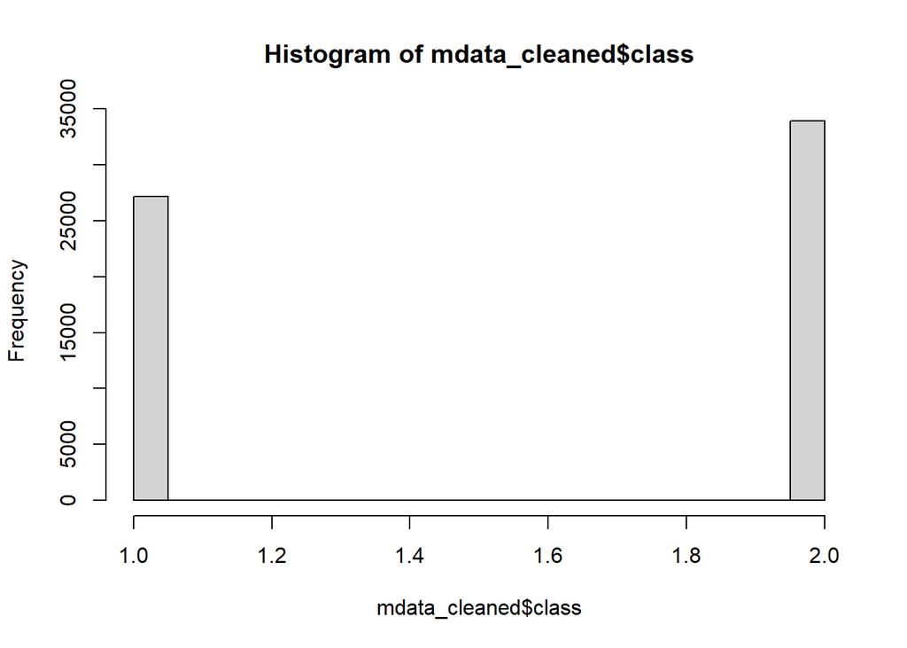

```r
hist(mdata_cleaned$class)
```

```r
table(mdata_cleaned$class)
```

```
##
##     1     2
## 27181 33888
```

### Distributions of Categorical Variables

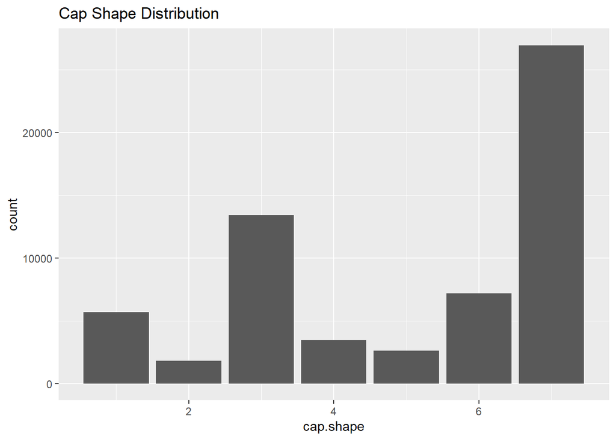

```r
library(ggplot2)
#Distributions of Categorical Variables
ggplot(data = mdata_cleaned, aes(x = cap.shape)) + geom_bar() + labs(title = "Cap Shape Distribution")
```

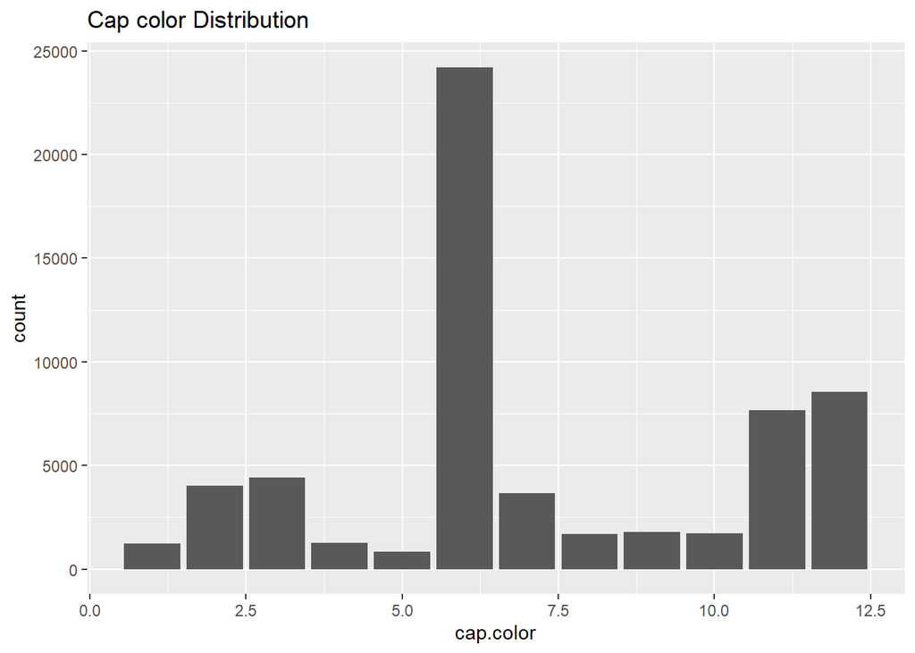

```r
ggplot(data = mdata_cleaned, aes(x = cap.color)) + geom_bar() + labs(title = "Cap color Distribution")
```

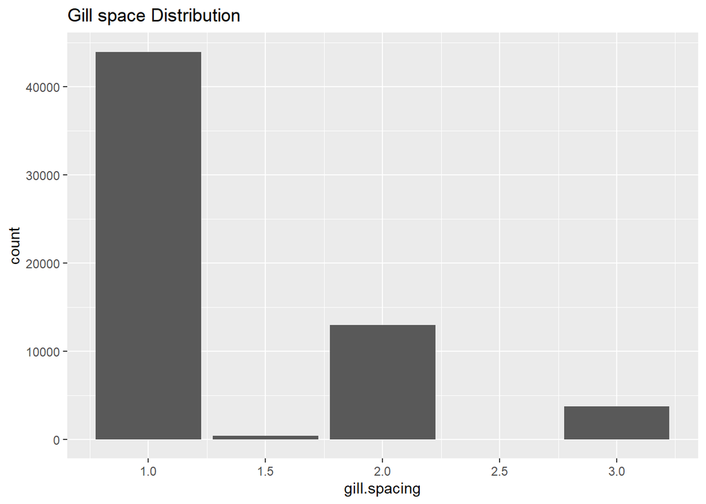

```r
ggplot(data = mdata_cleaned, aes(x = gill.spacing)) + geom_bar() + labs(title = "Gill space Distribution")
```

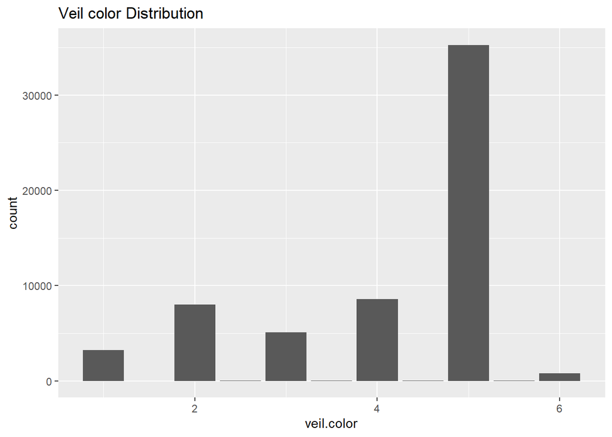

```r
ggplot(data = mdata_cleaned, aes(x = veil.color)) + geom_bar() + labs(title = "Veil color Distribution")
```

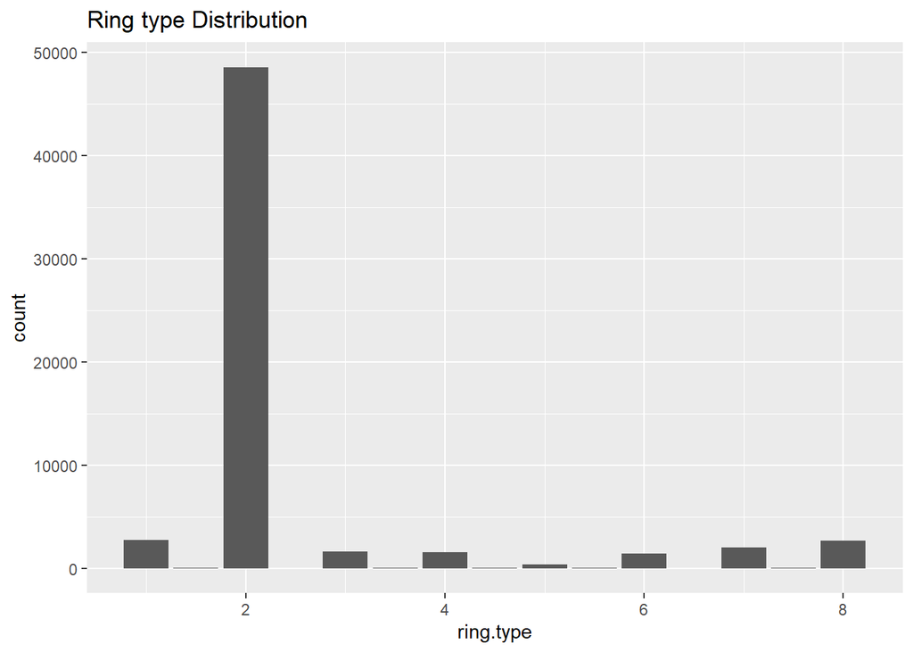

```r
ggplot(data = mdata_cleaned, aes(x = ring.type)) + geom_bar() + labs(title = "Ring type Distribution")
```

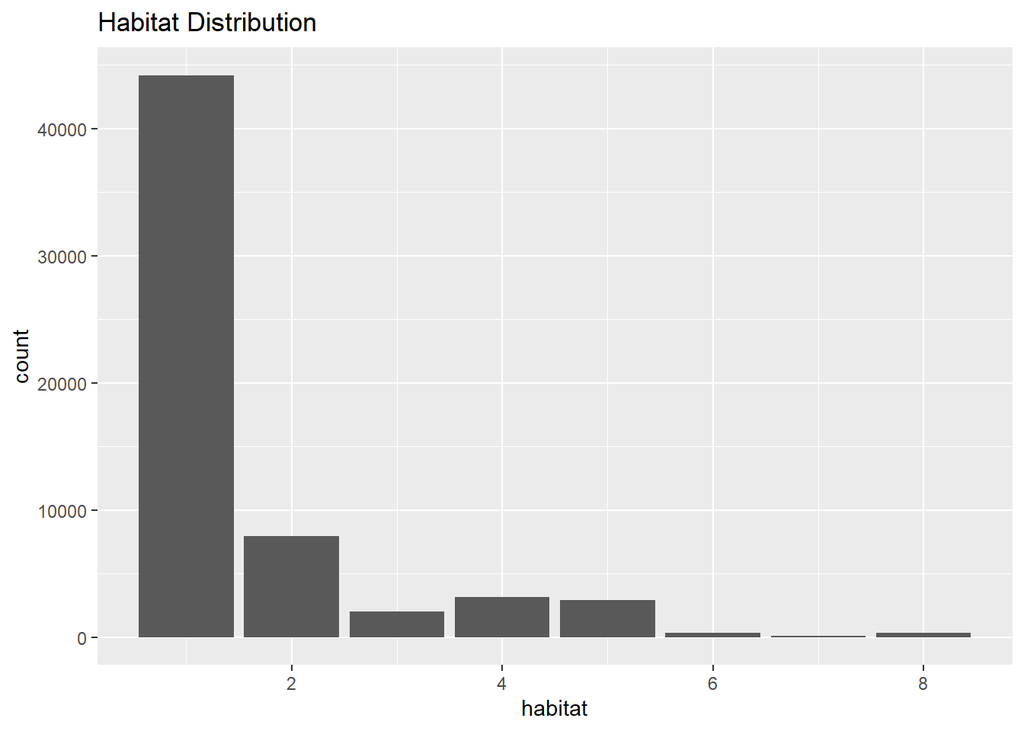

```r
ggplot(data = mdata_cleaned, aes(x = habitat)) + geom_bar() + labs(title = "Habitat Distribution")
```

### Visualizing Outliers using Boxplots

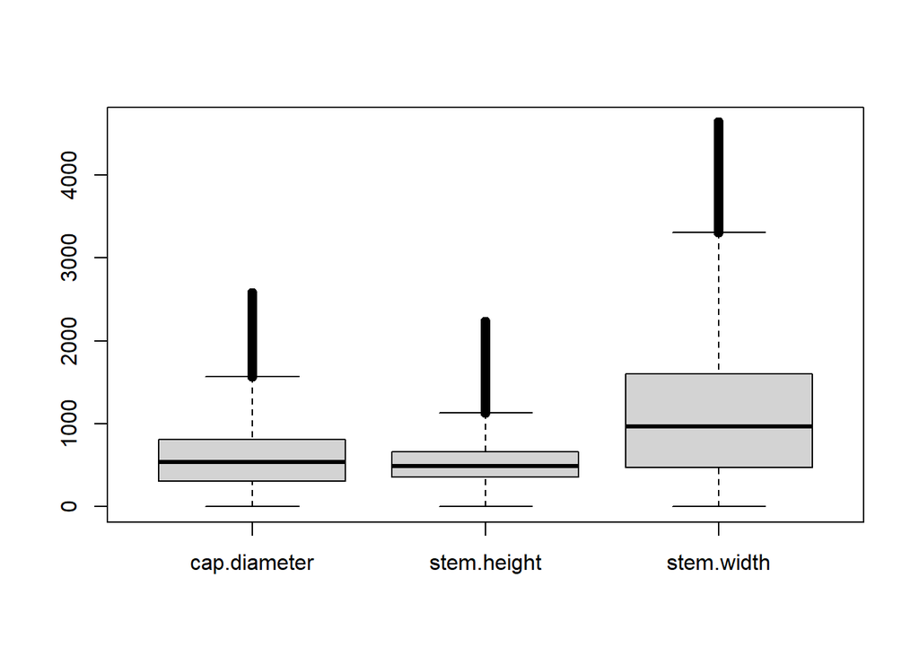

```r
# Boxplots of Numerical Variables
boxplot(missed.imputed[, c("cap.diameter", "stem.height", "stem.width")])
```

From the results of the Boxplot, there can be potential Outliers in the mushroom dataset

### Histogram Distribution of Numerical Variables

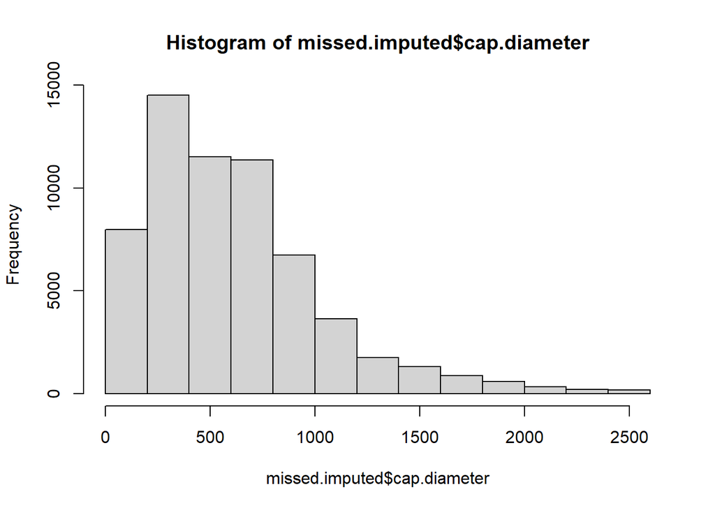

```r
hist(missed.imputed$cap.diameter)
```

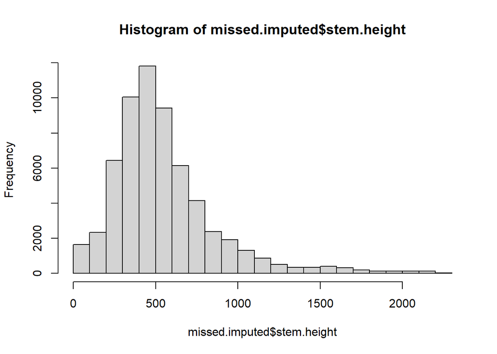

```r
hist(missed.imputed$stem.height)
```

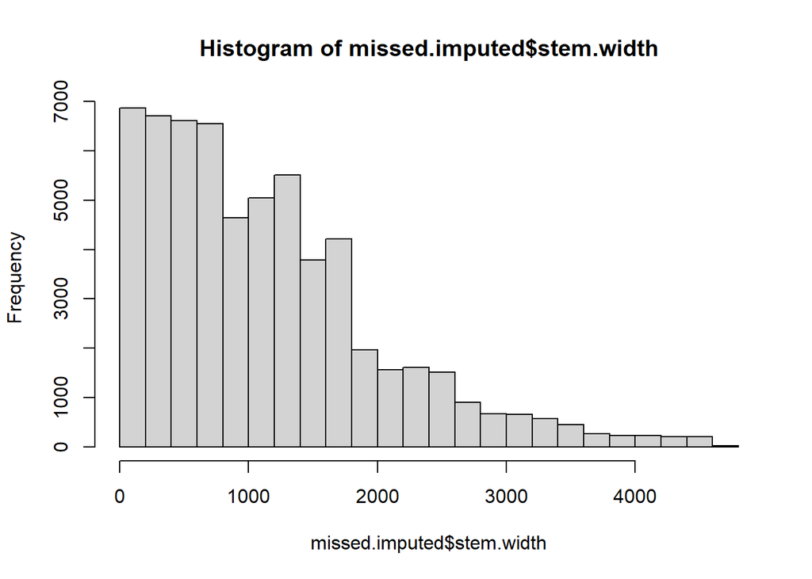

```r
hist(missed.imputed$stem.width)
```

From the Histograms, the distribution of the numerical variables in the mushroom dataset is not symmetric but slightly skewed to the right.

### Frequency Tables for Categorical Variables

```r
table(missed.imputed$cap.color)
```

```
##
##     1     2     3     4     5     6     7     8     9    10    11    12
##  1230  4035  4420  1279   828 24218  3656  1703  1782  1709  7666  8543
```

```r
table(missed.imputed$cap.surface)
```

```
##
##    1  1.5    2  2.5    3  3.5    4  4.5    5  5.5    6  6.5    7  7.5    8  8.5
## 5627    4 3705   37 5647  192 5669  101 3250   22 2888  257 2762  192 9925   27
##    9  9.5   10   11
## 8910   41 3835 7978
```

```r
table(missed.imputed$cap.shape)
```

```
##
##     1     2     3     4     5     6     7
##  5694  1815 13404  3460  2598  7164 26934
```

```r
table(missed.imputed$does.bruise.or.bleed)
```

```
##
##     1     2
## 50479 10590
```

```r
table(missed.imputed$gill.attachment)
```

```
##
##     1   1.5     2   2.5     3     4   4.5     5   5.5     6     7
## 14549    31 11536    41  7846  3948    27  6178    57  6994  9862
```

```r
table(missed.imputed$gill.color)
```

```
##
##     1     2     3     4     5     6     7     8     9    10    11    12
##   954  1066  3530  4118  2375  9645  2909  5983  1399  1023 18521  9546
```

```r
table(missed.imputed$stem.root)
```

```
##
##     1   1.5     2   2.5     3   3.5     4   4.5     5
## 30389   145  3934    58  3211    66  5706    54 17506
```

```r
table(missed.imputed$stem.surface)
```

```
##
##     1     2     3   3.5     4   4.5     5   5.5     6   6.5     7   7.5     8
##  1195  2725   591     6  9635    33  3372   309 18456   483 12709    75 11480
```

```r
table(missed.imputed$stem.color)
```

```
##
##     1     2     3     4     5     6     7     8     9    10    11    12    13
##   173  2050  1059  2626   837   226 18063  2187  1025   542  1490 22926  7865
```

```r
table(missed.imputed$veil.color)
```

```
##
##     1     2   2.5     3   3.5     4   4.5     5   5.5     6
##  3213  8028    12  5099    49  8563    43 35270    11   781
```

```r
table(missed.imputed$veil.type)
```

```
##
##     1
## 61069
```

```r
table(missed.imputed$has.ring)
```

```
##
##     1     2
## 45890 15179
```

```r
table(missed.imputed$ring.type)
```

```
##
##     1   1.5     2     3   3.5     4   4.5     5   5.5     6   6.5     7   7.5
##  2732     3 48562  1636     6  1543     3   376    61  1444     1  2038     6
##     8
##  2658
```

```r
table(missed.imputed$habitat)
```

```
##
##     1     2     3     4     5     6     7     8
## 44209  7943  2001  3168  2920   360   115   353
```

As you can see veil type has only one level so it is a irrelavant variable for the analysis

### Removing Irrelavant variable

```r
# Removing the column veil.type by setting it to NULL
mdata_cleaned$veil.type <- NULL
```

```r
str(mdata_cleaned)
```

```
## 'data.frame':    61069 obs. of  21 variables:
##  $ class               : num  2 2 2 2 2 2 2 2 2 2 ...
##  $ cap.diameter        : num  1482 1615 1363 1373 1420 ...
##  $ cap.shape           : num  7 7 7 3 7 7 3 7 3 3 ...
##  $ cap.surface         : num  3 3 3 4 4 3 4 4 3 3 ...
##  $ cap.color           : num  7 7 7 2 7 7 7 2 7 2 ...
##  $ does.bruise.or.bleed: num  1 1 1 1 1 1 1 1 1 1 ...
##  $ gill.attachment     : num  3 3 3 3 3 3 3 3 3 3 ...
##  $ gill.spacing        : num  1 1 1 1 1 1 1 1 1 1 ...
##  $ gill.color          : num  11 11 11 11 11 11 11 11 11 11 ...
##  $ stem.height         : num  1578 1682 1663 1464 1538 ...
##  $ stem.width          : num  1657 1767 1722 1546 1668 ...
##  $ stem.root           : num  5 5 5 5 5 5 5 5 5 5 ...
##  $ stem.surface        : num  8 8 8 8 8 8 8 8 8 8 ...
##  $ stem.color          : num  12 12 12 12 12 12 12 12 12 12 ...
##  $ veil.color          : num  5 5 5 5 5 5 5 5 5 5 ...
##  $ has.ring            : num  2 2 2 2 2 2 2 2 2 2 ...
##  $ ring.type           : num  3 3 3 6 6 6 3 6 6 6 ...
##  $ spore.print.color   : num  3 4.5 3 5 3 3 5 3 5 3 ...
##  $ habitat             : num  1 1 1 1 1 1 1 1 1 1 ...
##  $ season              : num  4 3 4 4 4 3 4 3 1 4 ...
##  $ class.1             : chr  "p" "p" "p" "p" ...
```

### Dealing with Outliers

```r
# Loading necessary library
library(dplyr)

# Defining a function to remove outliers using IQR method
remove_outliers <- function(data, numeric_cols, k = 1.5) {
  outliers <- data %>%
    select(all_of(numeric_cols)) %>%
    sapply(function(x) {
      Q1 <- quantile(x, 0.25)
      Q3 <- quantile(x, 0.75)
      IQR <- Q3 - Q1
      lower_bound <- Q1 - k * IQR
      upper_bound <- Q3 + k * IQR
      x[x < lower_bound | x > upper_bound] <- NA
      return(x)
    })

  # Removing rows with outliers
  data <- data[complete.cases(outliers), ]

  return(data)
}

# Specifying numerical columns in dataset
numeric_cols <- c("cap.diameter", "stem.height", "stem.width")

# Removing outliers from the dataset
mdata_cleaned1 <- remove_outliers(mdata_cleaned, numeric_cols)

# Checking the dimensions of the dataset after removing outliers
dim(mdata_cleaned1)
```

```
## [1] 55762    21
```

```r
# Check how many rows were removed
original_count <- nrow(mdata_cleaned)
cleaned_count <- nrow(mdata_cleaned1)
cat("Original Row Count: ", original_count, "\n")
```

```
## Original Row Count:  61069
```

```r
cat("Cleaned Row Count (No Outliers): ", cleaned_count, "\n")
```

```
## Cleaned Row Count (No Outliers):  55762
```

```r
cat("Rows Removed: ", original_count - cleaned_count, "\n")
```

```
## Rows Removed:  5307
```

### Distribution of Numericals after dealing with Outliers

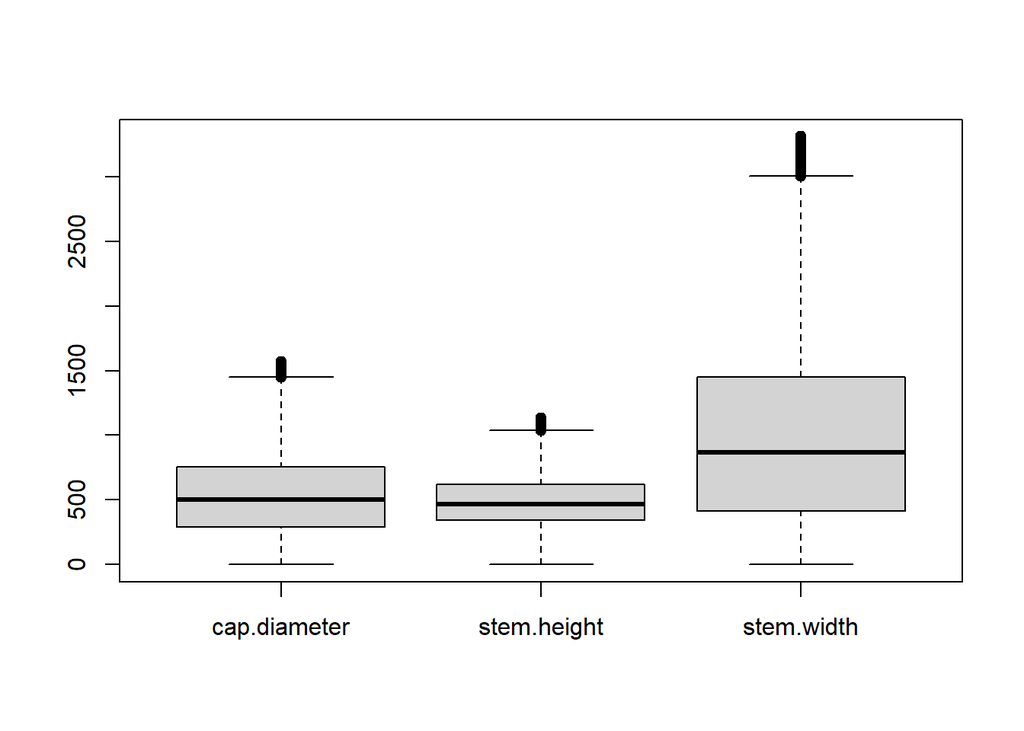

```r
# Boxplots of Numerical Variables
boxplot(mdata_cleaned1[, c("cap.diameter", "stem.height", "stem.width")])
```

From the results of box plot, we can say there are still outliers inspite of removing them

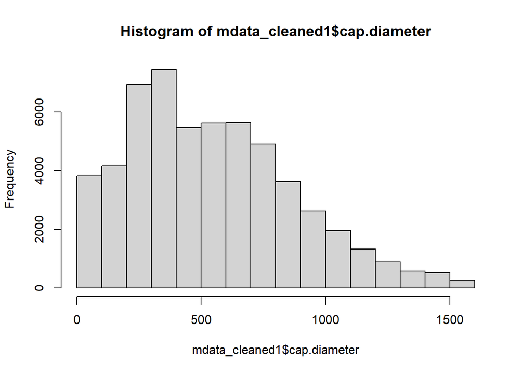

```r
hist(mdata_cleaned1$cap.diameter)
```

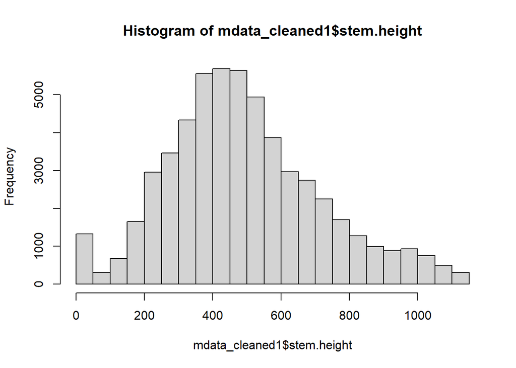

```r
hist(mdata_cleaned1$stem.height)
```

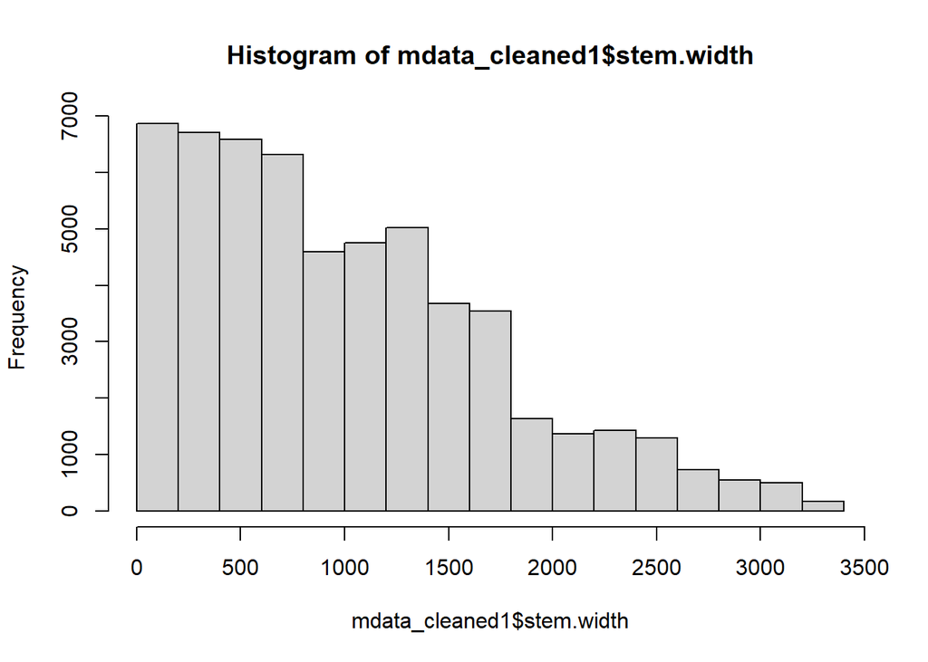

```r
hist(mdata_cleaned1$stem.width)
```

The histogram distributions of numerical variables are not symmetrical, but slightly right skewed.

### Creating Dummy variables

```r
library(caret)

# Creating dummy variables, excluding the response
dummies <- dummyVars(~ . -class, data = mdata_cleaned1)
mdata_transformed <- predict(dummies, newdata = mdata_cleaned1)

# Since the result is a matrix, converting it back to a data frame
mdata_transformed <- data.frame(mdata_transformed)

# Combining back the response
mdata_transformed$class <- mdata_cleaned1$class

# Checking that all columns are numeric
str(mdata_transformed)
```

```
## 'data.frame':    55762 obs. of  22 variables:
##  $ cap.diameter        : num  643 815 551 607 722 596 662 588 836 706 ...
##  $ cap.shape           : num  7 5 5 7 7 7 5 7 7 5 ...
##  $ cap.surface         : num  3 3 3 3 3 3 3 3 3 3 ...
##  $ cap.color           : num  6 6 6 6 6 6 6 6 6 6 ...
##  $ does.bruise.or.bleed: num  1 1 1 1 1 1 1 1 1 1 ...
##  $ gill.attachment     : num  3 3 3 3 3 3 3 3 3 3 ...
##  $ gill.spacing        : num  1 1 1 1 1 1 1 1 1 1 ...
##  $ gill.color          : num  11 11 11 11 11 11 11 11 11 11 ...
##  $ stem.height         : num  579 806 645 571 746 659 617 657 735 528 ...
##  $ stem.width          : num  1312 1682 1221 1240 1446 ...
##  $ stem.root           : num  5 5 5 5 5 5 5 5 5 5 ...
##  $ stem.surface        : num  8 8 8 8 8 8 8 8 8 8 ...
##  $ stem.color          : num  12 12 12 12 12 12 12 12 12 12 ...
##  $ veil.color          : num  5 5 5 5 5 5 5 5 5 5 ...
##  $ has.ring            : num  2 2 2 2 2 2 2 2 2 2 ...
##  $ ring.type           : num  6 6 6 6 6 6 6 6 6 6 ...
##  $ spore.print.color   : num  3 3 4.5 3 3 4.5 4.5 3 3 4.5 ...
##  $ habitat             : num  1 1 1 1 1 1 1 1 1 1 ...
##  $ season              : num  1 1 3 1 1 3 3 1 3 3 ...
##  $ class.1e            : num  0 0 0 0 0 0 0 0 0 0 ...
##  $ class.1p            : num  1 1 1 1 1 1 1 1 1 1 ...
##  $ class               : num  2 2 2 2 2 2 2 2 2 2 ...
```

## Feature Selection

### Anova

```r
# Performing ANOVA to select features
anova_results <- anova(lm(class ~ ., data = mdata_transformed))
# Viewing ANOVA results
print(anova_results)
```

```
## Analysis of Variance Table
##
## Response: class
##                         Df Sum Sq Mean Sq    F value    Pr(>F)
## cap.diameter             1  531.8   531.8 7.2832e+26 < 2.2e-16 ***
## cap.shape                1   70.3    70.3 9.6228e+25 < 2.2e-16 ***
## cap.surface              1   64.6    64.6 8.8506e+25 < 2.2e-16 ***
## cap.color                1   29.1    29.1 3.9865e+25 < 2.2e-16 ***
## does.bruise.or.bleed     1   19.2    19.2 2.6356e+25 < 2.2e-16 ***
## gill.attachment          1   13.8    13.8 1.8950e+25 < 2.2e-16 ***
## gill.spacing             1   47.6    47.6 6.5132e+25 < 2.2e-16 ***
## gill.color               1   42.3    42.3 5.7995e+25 < 2.2e-16 ***
## stem.height              1    1.5     1.5 2.1041e+24 < 2.2e-16 ***
## stem.width               1   31.0    31.0 4.2467e+25 < 2.2e-16 ***
## stem.root                1  250.4   250.4 3.4296e+26 < 2.2e-16 ***
## stem.surface             1  846.1   846.1 1.1587e+27 < 2.2e-16 ***
## stem.color               1   54.6    54.6 7.4782e+25 < 2.2e-16 ***
## veil.color               1 4288.3  4288.3 5.8730e+27 < 2.2e-16 ***
## has.ring                 1  288.5   288.5 3.9505e+26 < 2.2e-16 ***
## ring.type                1    9.2     9.2 1.2623e+25 < 2.2e-16 ***
## spore.print.color        1   14.7    14.7 2.0102e+25 < 2.2e-16 ***
## habitat                  1  122.6   122.6 1.6798e+26 < 2.2e-16 ***
## season                   1    8.7     8.7 1.1871e+25 < 2.2e-16 ***
## class.1e                 1 6990.9  6990.9 9.5744e+27 < 2.2e-16 ***
## Residuals            55741    0.0     0.0
## ---
## Signif. codes:  0 '***' 0.001 '**' 0.01 '*' 0.05 '.' 0.1 ' ' 1
```

From the Analysis of variance results, it says that all the variables are highly significant. This may occur due to High corelation and we can visualize it in correlation matrix.

### Calculating Correlation Matrix

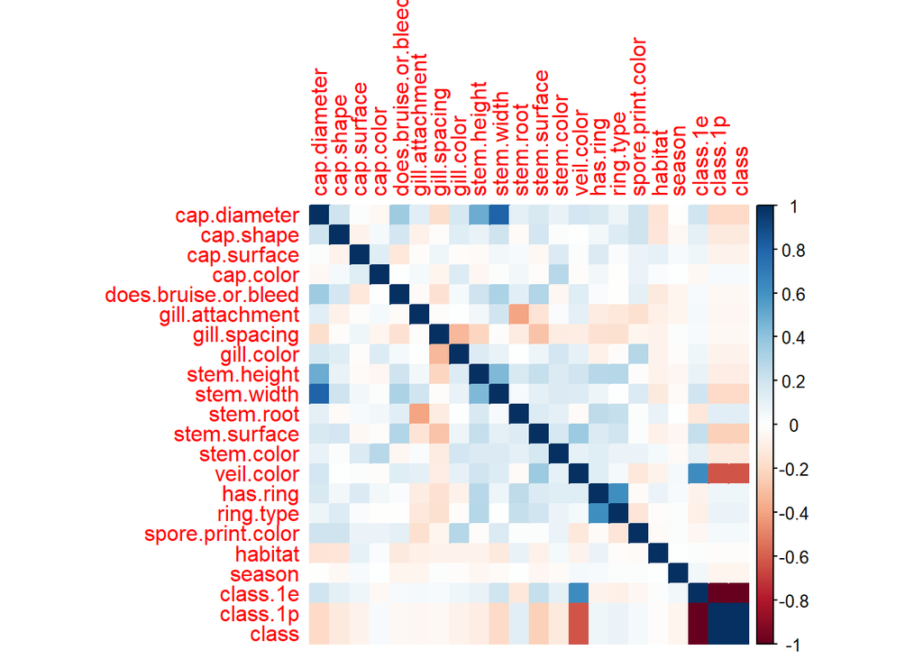

```r
# Calculating the correlation matrix, ensuring all are numeric
cor_matrix <- cor(mdata_transformed, use = "pairwise.complete.obs")

# Loading library for plotting
library(corrplot)

# Plotting the correlation matrix
corrplot(cor_matrix, method = "color")
```

```r
library(ggplot2)
library(factoextra)
```

```r
# Identifying constant columns
constant_columns <- sapply(mdata_transformed, function(x) length(unique(x)) == 1)

# Summarizing how many constant columns there are
cat("Number of constant columns:", sum(constant_columns), "\n")
```

```
## Number of constant columns: 0
```

```r
# Removing constant columns from the dataset
mdata_transformed <- mdata_transformed[, !constant_columns]

# Checking the structure to ensure constant columns are removed
str(mdata_transformed)
```

```
## 'data.frame':    55762 obs. of  22 variables:
##  $ cap.diameter        : num  643 815 551 607 722 596 662 588 836 706 ...
##  $ cap.shape           : num  7 5 5 7 7 7 5 7 7 5 ...
##  $ cap.surface         : num  3 3 3 3 3 3 3 3 3 3 ...
##  $ cap.color           : num  6 6 6 6 6 6 6 6 6 6 ...
##  $ does.bruise.or.bleed: num  1 1 1 1 1 1 1 1 1 1 ...
##  $ gill.attachment     : num  3 3 3 3 3 3 3 3 3 3 ...
##  $ gill.spacing        : num  1 1 1 1 1 1 1 1 1 1 ...
##  $ gill.color          : num  11 11 11 11 11 11 11 11 11 11 ...
##  $ stem.height         : num  579 806 645 571 746 659 617 657 735 528 ...
##  $ stem.width          : num  1312 1682 1221 1240 1446 ...
##  $ stem.root           : num  5 5 5 5 5 5 5 5 5 5 ...
##  $ stem.surface        : num  8 8 8 8 8 8 8 8 8 8 ...
##  $ stem.color          : num  12 12 12 12 12 12 12 12 12 12 ...
##  $ veil.color          : num  5 5 5 5 5 5 5 5 5 5 ...
##  $ has.ring            : num  2 2 2 2 2 2 2 2 2 2 ...
##  $ ring.type           : num  6 6 6 6 6 6 6 6 6 6 ...
##  $ spore.print.color   : num  3 3 4.5 3 3 4.5 4.5 3 3 4.5 ...
##  $ habitat             : num  1 1 1 1 1 1 1 1 1 1 ...
##  $ season              : num  1 1 3 1 1 3 3 1 3 3 ...
##  $ class.1e            : num  0 0 0 0 0 0 0 0 0 0 ...
##  $ class.1p            : num  1 1 1 1 1 1 1 1 1 1 ...
##  $ class               : num  2 2 2 2 2 2 2 2 2 2 ...
```

### Checking for zero variance predictors

```r
library(caret)

# Checking for near-zero variance predictors
nzv <- nearZeroVar(mdata_transformed, saveMetrics = TRUE)
low_variance_cols <- nzv[nzv$nzv,]

# Printing out low variance columns to check
print(low_variance_cols)
```

```
## [1] freqRatio     percentUnique zeroVar       nzv
## <0 rows> (or 0-length row.names)
```

```r
# Removing low variance columns from the dataset
mdata_transformed <- mdata_transformed[, !nzv$nzv]

# Checking the modified structure
str(mdata_transformed)
```

```
## 'data.frame':    55762 obs. of  22 variables:
##  $ cap.diameter        : num  643 815 551 607 722 596 662 588 836 706 ...
##  $ cap.shape           : num  7 5 5 7 7 7 5 7 7 5 ...
##  $ cap.surface         : num  3 3 3 3 3 3 3 3 3 3 ...
##  $ cap.color           : num  6 6 6 6 6 6 6 6 6 6 ...
##  $ does.bruise.or.bleed: num  1 1 1 1 1 1 1 1 1 1 ...
##  $ gill.attachment     : num  3 3 3 3 3 3 3 3 3 3 ...
##  $ gill.spacing        : num  1 1 1 1 1 1 1 1 1 1 ...
##  $ gill.color          : num  11 11 11 11 11 11 11 11 11 11 ...
##  $ stem.height         : num  579 806 645 571 746 659 617 657 735 528 ...
##  $ stem.width          : num  1312 1682 1221 1240 1446 ...
##  $ stem.root           : num  5 5 5 5 5 5 5 5 5 5 ...
##  $ stem.surface        : num  8 8 8 8 8 8 8 8 8 8 ...
##  $ stem.color          : num  12 12 12 12 12 12 12 12 12 12 ...
##  $ veil.color          : num  5 5 5 5 5 5 5 5 5 5 ...
##  $ has.ring            : num  2 2 2 2 2 2 2 2 2 2 ...
##  $ ring.type           : num  6 6 6 6 6 6 6 6 6 6 ...
##  $ spore.print.color   : num  3 3 4.5 3 3 4.5 4.5 3 3 4.5 ...
##  $ habitat             : num  1 1 1 1 1 1 1 1 1 1 ...
##  $ season              : num  1 1 3 1 1 3 3 1 3 3 ...
##  $ class.1e            : num  0 0 0 0 0 0 0 0 0 0 ...
##  $ class.1p            : num  1 1 1 1 1 1 1 1 1 1 ...
##  $ class               : num  2 2 2 2 2 2 2 2 2 2 ...
```

From the results it looks like there are no variables with zero variance

### Removing Highly corelated variables and Redundant variables

```r
# Removing cap.surface  and gill.color. This step is being performed after the identification of overfitting of the model
mdata_filtered <- mdata_transformed[, !(colnames(mdata_transformed) %in% c("cap.surface", "gill.color", "class.1e", "class.1p"))]
str(mdata_filtered)
```

```
## 'data.frame':    55762 obs. of  18 variables:
##  $ cap.diameter        : num  643 815 551 607 722 596 662 588 836 706 ...
##  $ cap.shape           : num  7 5 5 7 7 7 5 7 7 5 ...
##  $ cap.color           : num  6 6 6 6 6 6 6 6 6 6 ...
##  $ does.bruise.or.bleed: num  1 1 1 1 1 1 1 1 1 1 ...
##  $ gill.attachment     : num  3 3 3 3 3 3 3 3 3 3 ...
##  $ gill.spacing        : num  1 1 1 1 1 1 1 1 1 1 ...
##  $ stem.height         : num  579 806 645 571 746 659 617 657 735 528 ...
##  $ stem.width          : num  1312 1682 1221 1240 1446 ...
##  $ stem.root           : num  5 5 5 5 5 5 5 5 5 5 ...
##  $ stem.surface        : num  8 8 8 8 8 8 8 8 8 8 ...
##  $ stem.color          : num  12 12 12 12 12 12 12 12 12 12 ...
##  $ veil.color          : num  5 5 5 5 5 5 5 5 5 5 ...
##  $ has.ring            : num  2 2 2 2 2 2 2 2 2 2 ...
##  $ ring.type           : num  6 6 6 6 6 6 6 6 6 6 ...
##  $ spore.print.color   : num  3 3 4.5 3 3 4.5 4.5 3 3 4.5 ...
##  $ habitat             : num  1 1 1 1 1 1 1 1 1 1 ...
##  $ season              : num  1 1 3 1 1 3 3 1 3 3 ...
##  $ class               : num  2 2 2 2 2 2 2 2 2 2 ...
```

### Principal Component Analysis and Normalizing the data

```r
pca_result <- prcomp(mdata_filtered, scale. = TRUE, center = TRUE)

# Summarizing the PCA results
summary(pca_result)
```

```
## Importance of components:
##                           PC1    PC2     PC3     PC4     PC5     PC6     PC7
## Standard deviation     1.7716 1.4308 1.28357 1.16866 1.14797 1.05826 1.04704
## Proportion of Variance 0.1744 0.1137 0.09153 0.07588 0.07321 0.06222 0.06091
## Cumulative Proportion  0.1744 0.2881 0.37963 0.45551 0.52872 0.59094 0.65184
##                            PC8     PC9    PC10    PC11    PC12    PC13    PC14
## Standard deviation     0.98778 0.95891 0.89453 0.82997 0.79273 0.72939 0.68918
## Proportion of Variance 0.05421 0.05108 0.04445 0.03827 0.03491 0.02956 0.02639
## Cumulative Proportion  0.70605 0.75713 0.80159 0.83986 0.87477 0.90433 0.93071
##                           PC15    PC16    PC17    PC18
## Standard deviation     0.68295 0.59296 0.51845 0.40044
## Proportion of Variance 0.02591 0.01953 0.01493 0.00891
## Cumulative Proportion  0.95663 0.97616 0.99109 1.00000
```

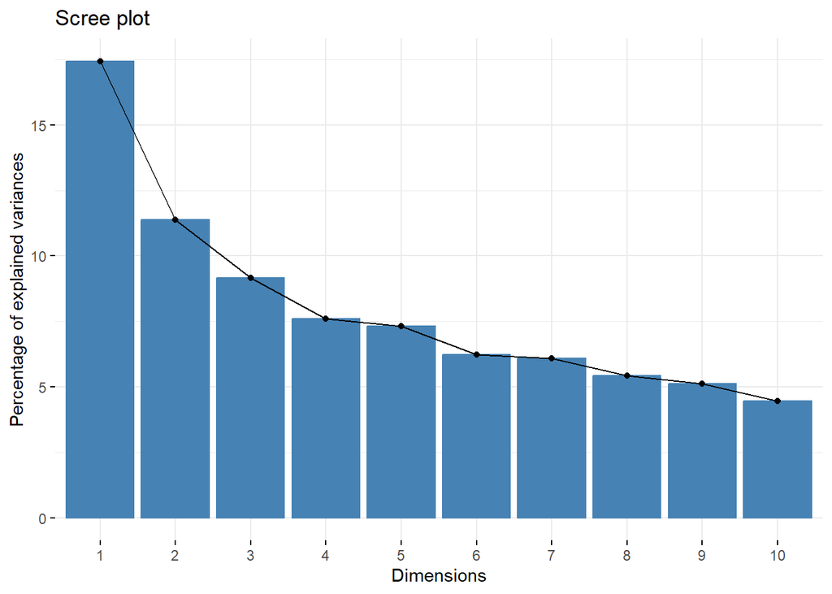

```r
# Visualizing the variance explained by the principal components
library(factoextra)
fviz_eig(pca_result)
```

It looks like the elbow lies in the region of the 4th or 5th principal component. It may be that the first four principal components capture a good deal of variation in the data.

### PCA Biplot

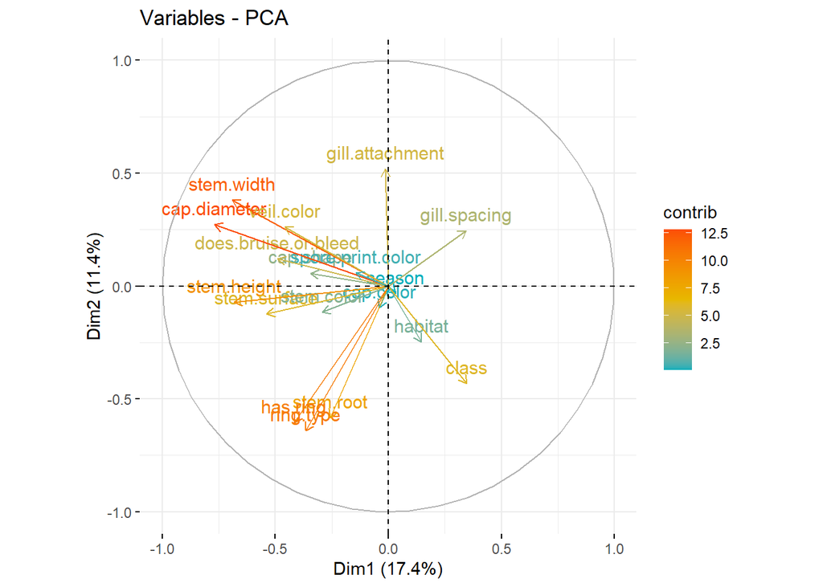

```r
#Visualizing PCA biplot
fviz_pca_var(pca_result, col.var = "contrib",
             gradient.cols = c("#00AFBB", "#E7B800", "#FC4E07")
             )
```

### Selecting Features from the original dataset

```r
# List of selected feature names based on PCA biplot correlation with the class
selected_features <- c("habitat", "stem.width", "cap.diameter", "does.bruise.or.bleed",
                       "veil.color", "season", "spore.print.color", "cap.shape", "class")


# Creating a new dataset with only the selected features
selected_data <- mdata_filtered[, selected_features]

# Checking the structure of the new dataset to confirm the features are correctly selected
str(selected_data)
```

```
## 'data.frame':    55762 obs. of  9 variables:
##  $ habitat             : num  1 1 1 1 1 1 1 1 1 1 ...
##  $ stem.width          : num  1312 1682 1221 1240 1446 ...
##  $ cap.diameter        : num  643 815 551 607 722 596 662 588 836 706 ...
##  $ does.bruise.or.bleed: num  1 1 1 1 1 1 1 1 1 1 ...
##  $ veil.color          : num  5 5 5 5 5 5 5 5 5 5 ...
##  $ season              : num  1 1 3 1 1 3 3 1 3 3 ...
##  $ spore.print.color   : num  3 3 4.5 3 3 4.5 4.5 3 3 4.5 ...
##  $ cap.shape           : num  7 5 5 7 7 7 5 7 7 5 ...
##  $ class               : num  2 2 2 2 2 2 2 2 2 2 ...
```

### PCA biplot for selected features

```r
#  PCA
pca_result1 <- prcomp(selected_data, scale. = TRUE, center = TRUE)

# Summarizing the PCA results
summary(pca_result1)
```

```
## Importance of components:
##                          PC1    PC2    PC3    PC4    PC5     PC6     PC7
## Standard deviation     1.556 1.2486 1.0109 0.9964 0.9792 0.88770 0.85789
## Proportion of Variance 0.269 0.1732 0.1135 0.1103 0.1065 0.08756 0.08177
## Cumulative Proportion  0.269 0.4422 0.5558 0.6661 0.7726 0.86017 0.94194
##                            PC8     PC9
## Standard deviation     0.58102 0.43006
## Proportion of Variance 0.03751 0.02055
## Cumulative Proportion  0.97945 1.00000
```

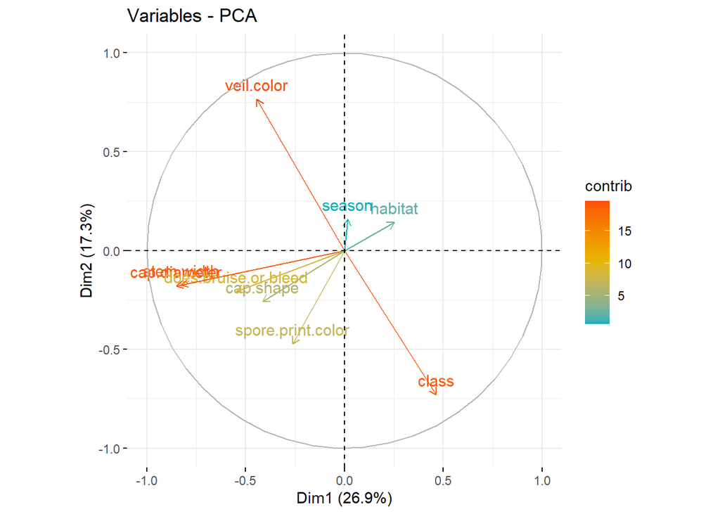

```r
fviz_pca_var(pca_result1, col.var = "contrib",
             gradient.cols = c("#00AFBB", "#E7B800", "#FC4E07")
             )
```

### Corelation matrix for the selected features

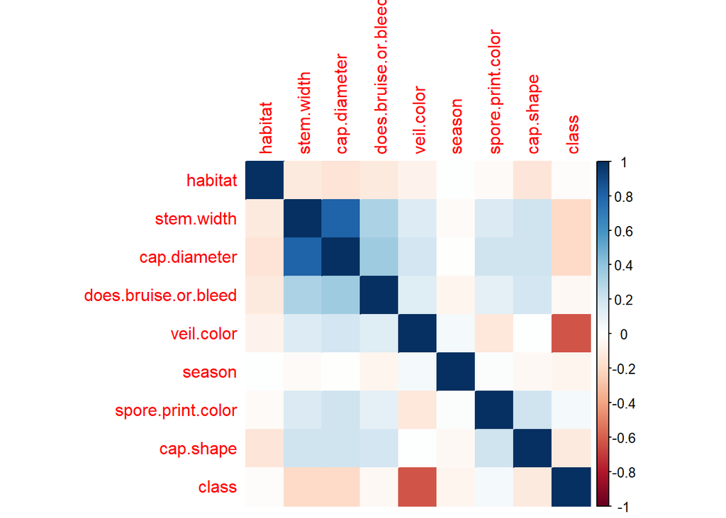

```r
# Calculating the correlation matrix, ensuring all are numeric
cor_matrix2 <- cor(selected_data, use = "pairwise.complete.obs")

# Loading library for plotting
library(corrplot)

# Plotting the correlation matrix
corrplot(cor_matrix2, method = "color")
```

### Pair Metrics

```r
library(GGally)
```

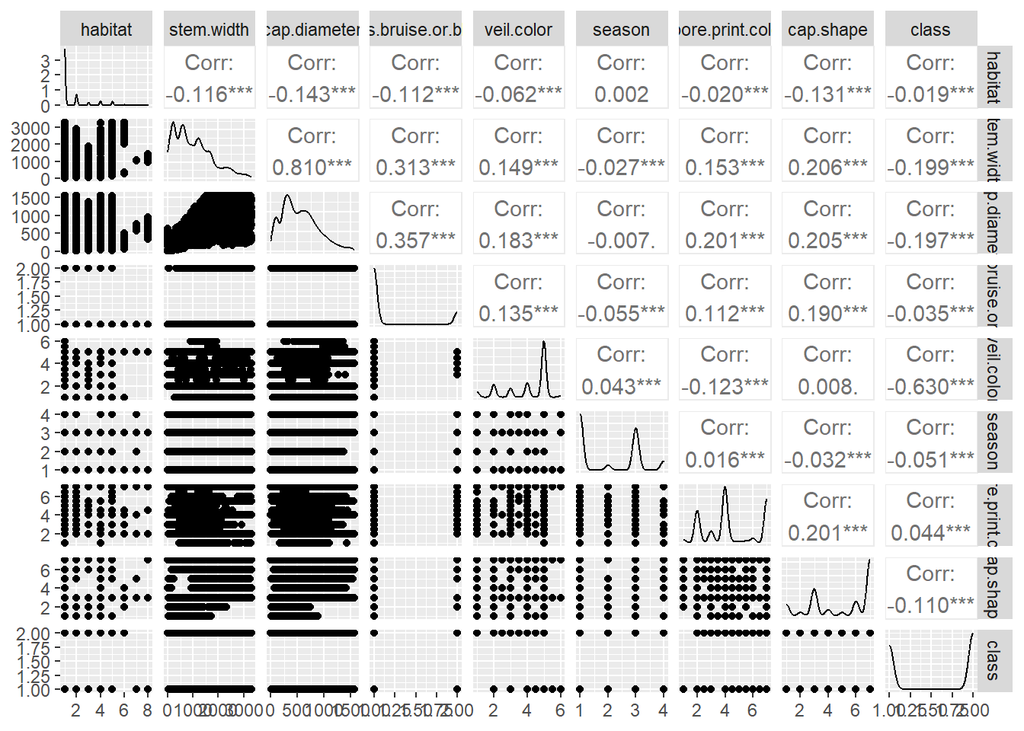

```r
ggpairs(selected_data)
```

### Normalizing the Data

```r
# Standardizing the data
norm_data <- scale(selected_data[, -which(names(selected_data) == "class")])  # Assuming 'class' should not be normalized


norm_data <- as.data.frame(norm_data)  # Convert to data frame
norm_data$class <- selected_data$class

head(norm_data)
```

```
##       habitat stem.width cap.diameter does.bruise.or.bleed veil.color
## 354 -0.505442  0.4204293   0.30437976           -0.4672027  0.6956706
## 355 -0.505442  0.9248960   0.82689981           -0.4672027  0.6956706
## 356 -0.505442  0.2963578   0.02489229           -0.4672027  0.6956706
## 357 -0.505442  0.3222628   0.19501510           -0.4672027  0.6956706
## 358 -0.505442  0.6031281   0.54437443           -0.4672027  0.6956706
## 359 -0.505442  0.5622254   0.16159812           -0.4672027  0.6956706
##         season spore.print.color  cap.shape class
## 354 -0.9486375       -0.71595202  0.8987353     2
## 355 -0.9486375       -0.71595202 -0.0288616     2
## 356  0.8793369        0.07433475 -0.0288616     2
## 357 -0.9486375       -0.71595202  0.8987353     2
## 358 -0.9486375       -0.71595202  0.8987353     2
## 359  0.8793369        0.07433475  0.8987353     2
```

### Building kNN model

```r
library(caret)
library(class)
library(gmodels)  # for confusion matrix
```

```r
# Convert the target variable to a factor if it isn't already
norm_data$class <- as.factor(norm_data$class)
```

### Finding the optimal k - hyperparameter

```r
library(caret)

# Set seed for reproducibility
set.seed(123)

# Creating a training control object specifying cross-validation
train_control <- trainControl(
  method = "cv",        # Cross-validation
  number = 10           # Number of folds
)

# Defining the range of k values to try
k_values <- expand.grid(k = seq(1, 20
                                , by = 2))  # Testing odd k values from 1 to 20


x <- norm_data[, names(norm_data) != "class"]
y <- norm_data$class

# Train the KNN model using caret to find the optimal k without additional scaling
knn_results <- train(
  x, y,
  method = "knn",
  tuneGrid = k_values,
  trControl = train_control,
  metric = "Accuracy"    # specify accuracy as the performance metric
)

# Print out the results
print(knn_results)
```

```
## k-Nearest Neighbors
##
## 55762 samples
##     8 predictor
##     2 classes: '1', '2'
##
## No pre-processing
## Resampling: Cross-Validated (10 fold)
## Summary of sample sizes: 50185, 50185, 50186, 50186, 50186, 50187, ...
## Resampling results across tuning parameters:
##
##   k   Accuracy   Kappa
##    1  0.9853486  0.9702368
##    3  0.9876978  0.9750147
##    5  0.9875184  0.9746510
##    7  0.9865141  0.9726161
##    9  0.9861734  0.9719270
##   11  0.9857430  0.9710568
##   13  0.9849181  0.9693869
##   15  0.9840573  0.9676466
##   17  0.9830530  0.9656160
##   19  0.9821025  0.9636883
##
## Accuracy was used to select the optimal model using the largest value.
## The final value used for the model was k = 3.
```

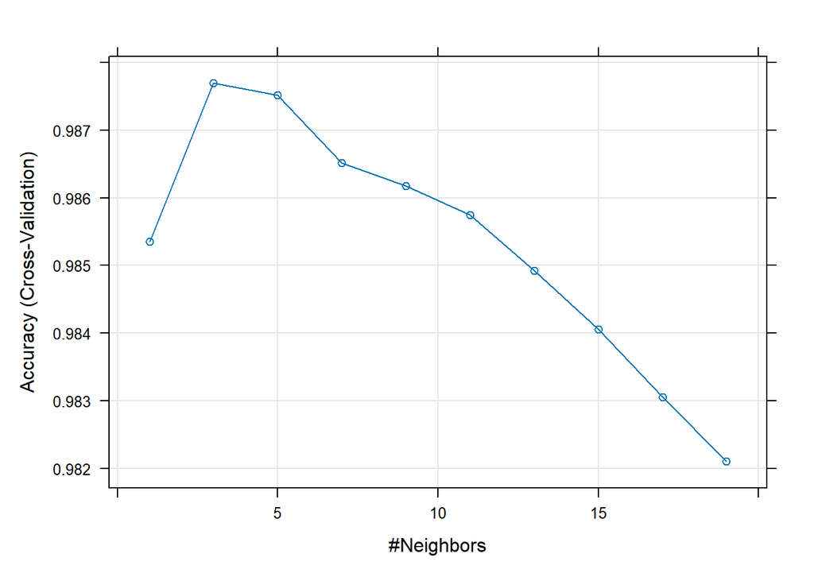

```r
# Visualize the accuracy across different k values
plot(knn_results)
```

```r
# Extract the best k value
best_k <- knn_results$bestTune$k
cat("The optimal k value is:", best_k, "\n")
```

```
## The optimal k value is: 3
```

### Data splitting

```r
# Loading necessary library
library(caret)

# Set seed for reproducibility
set.seed(123)

response <- norm_data$class

# Splitting data into training and test sets using createDataPartition
train_index <- createDataPartition(response, p = 0.8, list = FALSE)
train_data <- norm_data[train_index, ]
train_labels <- response[train_index]  # Extracting training labels
test_data <- norm_data[-train_index, ]
test_labels <- response[-train_index]  # Extracting testing labels

# Ensuring all datasets are correctly formed
str(train_data)
```

```
## 'data.frame':    44610 obs. of  9 variables:
##  $ habitat             : num  -0.505 -0.505 -0.505 -0.505 -0.505 ...
##  $ stem.width          : num  0.42 0.296 0.322 0.562 0.72 ...
##  $ cap.diameter        : num  0.3044 0.0249 0.195 0.1616 0.1373 ...
##  $ does.bruise.or.bleed: num  -0.467 -0.467 -0.467 -0.467 -0.467 ...
##  $ veil.color          : num  0.696 0.696 0.696 0.696 0.696 ...
##  $ season              : num  -0.949 0.879 -0.949 0.879 -0.949 ...
##  $ spore.print.color   : num  -0.716 0.0743 -0.716 0.0743 -0.716 ...
##  $ cap.shape           : num  0.8987 -0.0289 0.8987 0.8987 0.8987 ...
##  $ class               : Factor w/ 2 levels "1","2": 2 2 2 2 2 2 2 2 2 2 ...
```

```r
str(train_labels)
```

```
##  Factor w/ 2 levels "1","2": 2 2 2 2 2 2 2 2 2 2 ...
```

```r
str(test_data)
```

```
## 'data.frame':    11152 obs. of  9 variables:
##  $ habitat             : num  -0.505 -0.505 -0.505 -0.505 -0.505 ...
##  $ stem.width          : num  0.925 0.603 0.201 0.262 0.832 ...
##  $ cap.diameter        : num  0.827 0.544 0.362 0.235 0.924 ...
##  $ does.bruise.or.bleed: num  -0.467 -0.467 -0.467 -0.467 -0.467 ...
##  $ veil.color          : num  0.696 0.696 0.696 0.696 0.696 ...
##  $ season              : num  -0.949 -0.949 0.879 -0.949 0.879 ...
##  $ spore.print.color   : num  -0.716 -0.716 0.0743 0.3378 -0.716 ...
##  $ cap.shape           : num  -0.0289 0.8987 -0.0289 -0.0289 0.8987 ...
##  $ class               : Factor w/ 2 levels "1","2": 2 2 2 2 2 2 2 2 2 2 ...
```

```r
str(test_labels)
```

```
##  Factor w/ 2 levels "1","2": 2 2 2 2 2 2 2 2 2 2 ...
```

```r
library(gmodels)
# Performing kNN classification and evaluate
perform_knn <- function(k) {
  knn_pred <- knn(train = train_data, test = test_data, cl = train_labels, k = k)
  conf_mat <- CrossTable(x = test_labels, y = knn_pred, prop.chisq = FALSE)  # confusion matrix
  acc <- sum(diag(conf_mat$t)) / sum(conf_mat$t)  # calculating accuracy
  list(accuracy = acc, confusion_matrix = conf_mat)
}
```

```r
# Trying k =1, 3, 4, 5
results_k1 <- perform_knn(1)
```

```
##
##
##    Cell Contents
## |-------------------------|
## |                       N |
## |           N / Row Total |
## |           N / Col Total |
## |         N / Table Total |
## |-------------------------|
##
##
## Total Observations in Table:  11152
##
##
##              | knn_pred
##  test_labels |         1 |         2 | Row Total |
## -------------|-----------|-----------|-----------|
##            1 |      4883 |         0 |      4883 |
##              |     1.000 |     0.000 |     0.438 |
##              |     1.000 |     0.000 |           |
##              |     0.438 |     0.000 |           |
## -------------|-----------|-----------|-----------|
##            2 |         0 |      6269 |      6269 |
##              |     0.000 |     1.000 |     0.562 |
##              |     0.000 |     1.000 |           |
##              |     0.000 |     0.562 |           |
## -------------|-----------|-----------|-----------|
## Column Total |      4883 |      6269 |     11152 |
##              |     0.438 |     0.562 |           |
## -------------|-----------|-----------|-----------|
##
##
```

```r
results_k3 <- perform_knn(3)
```

```
##
##
##    Cell Contents
## |-------------------------|
## |                       N |
## |           N / Row Total |
## |           N / Col Total |
## |         N / Table Total |
## |-------------------------|
##
##
## Total Observations in Table:  11152
##
##
##              | knn_pred
##  test_labels |         1 |         2 | Row Total |
## -------------|-----------|-----------|-----------|
##            1 |      4883 |         0 |      4883 |
##              |     1.000 |     0.000 |     0.438 |
##              |     1.000 |     0.000 |           |
##              |     0.438 |     0.000 |           |
## -------------|-----------|-----------|-----------|
##            2 |         0 |      6269 |      6269 |
##              |     0.000 |     1.000 |     0.562 |
##              |     0.000 |     1.000 |           |
##              |     0.000 |     0.562 |           |
## -------------|-----------|-----------|-----------|
## Column Total |      4883 |      6269 |     11152 |
##              |     0.438 |     0.562 |           |
## -------------|-----------|-----------|-----------|
##
##
```

```r
results_k4 <- perform_knn(4)
```

```
##
##
##    Cell Contents
## |-------------------------|
## |                       N |
## |           N / Row Total |
## |           N / Col Total |
## |         N / Table Total |
## |-------------------------|
##
##
## Total Observations in Table:  11152
##
##
##              | knn_pred
##  test_labels |         1 |         2 | Row Total |
## -------------|-----------|-----------|-----------|
##            1 |      4883 |         0 |      4883 |
##              |     1.000 |     0.000 |     0.438 |
##              |     1.000 |     0.000 |           |
##              |     0.438 |     0.000 |           |
## -------------|-----------|-----------|-----------|
##            2 |         2 |      6267 |      6269 |
##              |     0.000 |     1.000 |     0.562 |
##              |     0.000 |     1.000 |           |
##              |     0.000 |     0.562 |           |
## -------------|-----------|-----------|-----------|
## Column Total |      4885 |      6267 |     11152 |
##              |     0.438 |     0.562 |           |
## -------------|-----------|-----------|-----------|
##
##
```

```r
results_k5 <- perform_knn(5)
```

```
##
##
##    Cell Contents
## |-------------------------|
## |                       N |
## |           N / Row Total |
## |           N / Col Total |
## |         N / Table Total |
## |-------------------------|
##
##
## Total Observations in Table:  11152
##
##
##              | knn_pred
##  test_labels |         1 |         2 | Row Total |
## -------------|-----------|-----------|-----------|
##            1 |      4883 |         0 |      4883 |
##              |     1.000 |     0.000 |     0.438 |
##              |     1.000 |     0.000 |           |
##              |     0.438 |     0.000 |           |
## -------------|-----------|-----------|-----------|
##            2 |         2 |      6267 |      6269 |
##              |     0.000 |     1.000 |     0.562 |
##              |     0.000 |     1.000 |           |
##              |     0.000 |     0.562 |           |
## -------------|-----------|-----------|-----------|
## Column Total |      4885 |      6267 |     11152 |
##              |     0.438 |     0.562 |           |
## -------------|-----------|-----------|-----------|
##
##
```

```r
# Print results
cat("Results for k = 1\n")
```

```
## Results for k = 1
```

```r
print(results_k1$accuracy)
```

```
## [1] 1
```

```r
print(results_k1$confusion_matrix)
```

```
## $t
##    y
## x      1    2
##   1 4883    0
##   2    0 6269
##
## $prop.row
##    y
## x   1 2
##   1 1 0
##   2 0 1
##
## $prop.col
##    y
## x   1 2
##   1 1 0
##   2 0 1
##
## $prop.tbl
##    y
## x           1         2
##   1 0.4378587 0.0000000
##   2 0.0000000 0.5621413
```

```r
cat("Results for k = 3\n")
```

```
## Results for k = 3
```

```r
print(results_k3$accuracy)
```

```
## [1] 1
```

```r
print(results_k3$confusion_matrix)
```

```
## $t
##    y
## x      1    2
##   1 4883    0
##   2    0 6269
##
## $prop.row
##    y
## x   1 2
##   1 1 0
##   2 0 1
##
## $prop.col
##    y
## x   1 2
##   1 1 0
##   2 0 1
##
## $prop.tbl
##    y
## x           1         2
##   1 0.4378587 0.0000000
##   2 0.0000000 0.5621413
```

```r
cat("Results for k = 4\n")
```

```
## Results for k = 4
```

```r
print(results_k4$accuracy)
```

```
## [1] 0.9998207
```

```r
print(results_k4$confusion_matrix)
```

```
## $t
##    y
## x      1    2
##   1 4883    0
##   2    2 6267
##
## $prop.row
##    y
## x              1            2
##   1 1.0000000000 0.0000000000
##   2 0.0003190301 0.9996809699
##
## $prop.col
##    y
## x              1            2
##   1 0.9995905834 0.0000000000
##   2 0.0004094166 1.0000000000
##
## $prop.tbl
##    y
## x            1          2
##   1 0.43785868 0.00000000
##   2 0.00017934 0.56196198
```

```r
cat("Results for k = 5\n")
```

```
## Results for k = 5
```

```r
print(results_k5$accuracy)
```

```
## [1] 0.9998207
```

```r
print(results_k5$confusion_matrix)
```

```
## $t
##    y
## x      1    2
##   1 4883    0
##   2    2 6267
##
## $prop.row
##    y
## x              1            2
##   1 1.0000000000 0.0000000000
##   2 0.0003190301 0.9996809699
##
## $prop.col
##    y
## x              1            2
##   1 0.9995905834 0.0000000000
##   2 0.0004094166 1.0000000000
##
## $prop.tbl
##    y
## x            1          2
##   1 0.43785868 0.00000000
##   2 0.00017934 0.56196198
```

The accuracy results across the k values shows near 100 % . Though it is impressive, it is highly unlikely and may resluts in potential overfitting. So we need to check for overfitting through cross validation.

### Performing Cross Validation to Check the Overfitting

```r
# Performing kNN classification with cross-validation
perform_knn_cv <- function(k) {
  set.seed(123)  # for reproducibility
  folds <- createFolds(train_labels, k = 5)  # create 5-fold cross-validation
  acc_scores <- numeric(length(folds))

  for (i in seq_along(folds)) {
    train_idx <- unlist(folds[-i])  # index for training data
    test_idx <- unlist(folds[i])  # index for test data

    train_data_cv <- train_data[train_idx, ]
    train_labels_cv <- train_labels[train_idx]
    test_data_cv <- train_data[test_idx, ]
    test_labels_cv <- train_labels[test_idx]

    knn_pred_cv <- knn(train = train_data_cv, test = test_data_cv, cl = train_labels_cv, k = k)
    conf_mat_cv <- confusionMatrix(knn_pred_cv, test_labels_cv)  # confusion matrix
    acc_scores[i] <- conf_mat_cv$overall['Accuracy']  # store accuracy
  }

  mean_accuracy <- mean(acc_scores)
  list(accuracy = mean_accuracy, accuracy_scores = acc_scores)
}
```

```r
# Trying k =1, 3, 4, 5 with cross-validation
cv_results_k1 <- perform_knn_cv(1)
cv_results_k3 <- perform_knn_cv(3)
cv_results_k4 <- perform_knn_cv(4)
cv_results_k5 <- perform_knn_cv(5)


# Printing cross-validation results
cat("Cross-validation Results for k = 1\n")
```

```
## Cross-validation Results for k = 1
```

```r
print(cv_results_k1$accuracy)
```

```
## [1] 0.9999328
```

```r
cat("Accuracy Scores:", cv_results_k3$accuracy_scores, "\n")
```

```
## Accuracy Scores: 1 0.9997758 0.9997759 0.9998879 0.9998879
```

```r
cat("Cross-validation Results for k = 3\n")
```

```
## Cross-validation Results for k = 3
```

```r
print(cv_results_k3$accuracy)
```

```
## [1] 0.9998655
```

```r
cat("Accuracy Scores:", cv_results_k3$accuracy_scores, "\n")
```

```
## Accuracy Scores: 1 0.9997758 0.9997759 0.9998879 0.9998879
```

```r
cat("Cross-validation Results for k = 4\n")
```

```
## Cross-validation Results for k = 4
```

```r
print(cv_results_k4$accuracy)
```

```
## [1] 0.9998431
```

```r
cat("Accuracy Scores:", cv_results_k4$accuracy_scores, "\n")
```

```
## Accuracy Scores: 1 0.9996638 0.9997759 0.9998879 0.9998879
```

```r
cat("Cross-validation Results for k = 5\n")
```

```
## Cross-validation Results for k = 5
```

```r
print(cv_results_k5$accuracy)
```

```
## [1] 0.9998207
```

```r
cat("Accuracy Scores:", cv_results_k5$accuracy_scores, "\n")
```

```
## Accuracy Scores: 1 0.9996638 0.9996638 0.9998879 0.9998879
```

## Naive Bayes Classification

```r
library(e1071)  # Loading the package necessary for Naive Bayes

# Training a Naive Bayes model
nb_model <- naiveBayes(train_data, as.factor(train_labels))

# Predicting using the model
nb_predictions <- predict(nb_model, test_data)

# Creating a confusion matrix
nb_conf_matrix <- confusionMatrix(as.factor(nb_predictions), as.factor(test_labels))



# Output of confusion matrix and accuracy
print(nb_conf_matrix)
```

```
## Confusion Matrix and Statistics
##
##           Reference
## Prediction    1    2
##          1 4730    0
##          2  153 6269
##
##                Accuracy : 0.9863
##                  95% CI : (0.9839, 0.9884)
##     No Information Rate : 0.5621
##     P-Value [Acc > NIR] : < 2.2e-16
##
##                   Kappa : 0.972
##
##  Mcnemar's Test P-Value : < 2.2e-16
##
##             Sensitivity : 0.9687
##             Specificity : 1.0000
##          Pos Pred Value : 1.0000
##          Neg Pred Value : 0.9762
##              Prevalence : 0.4379
##          Detection Rate : 0.4241
##    Detection Prevalence : 0.4241
##       Balanced Accuracy : 0.9843
##
##        'Positive' Class : 1
##
```

```r
cat("Accuracy of Naive Bayes Model:", nb_conf_matrix$overall['Accuracy'], "\n")
```

```
## Accuracy of Naive Bayes Model: 0.9862805
```

Inference: The Naive Bayes classifier has shown remarkable performance in classifying the given dataset, with an accuracy of 98.63% and 95% confidence interval of 98.39% to 98.84%. This degree of accuracy is remarkably better than the No Information Rate of 56.21%, given that the p-value is near zero, < 2.2e-16, which, thus, means that the model is not only more accurate than a naive approach but statistically significant. The model has almost perfect agreement between the predicted and actual classes: Kappa 0.972. For example, the sensitivity is 96.87%, and the specificity is 100%, which means that the model is relatively good at identifying positive and negative cases very well. Positive and Negative Predictive Values stand at 100% and 97.62%, respectively, which further shows the reliability of the model regarding its predictions. The balanced accuracy of 98.43% shows that the model’s classification is relatively stable in both positive and negative classes.

```r
# Performing cross-validation for Naive Bayes model
perform_nb_cv <- function(data, labels, folds) {
  set.seed(123)  # for reproducibility
  acc_scores <- numeric(length(folds))

  for (i in seq_along(folds)) {
    train_idx <- unlist(folds[-i])  # index for training data
    test_idx <- unlist(folds[i])  # index for test data

    train_data_cv <- data[train_idx, ]
    train_labels_cv <- labels[train_idx]
    test_data_cv <- data[test_idx, ]
    test_labels_cv <- labels[test_idx]

    nb_model_cv <- naiveBayes(train_data_cv, as.factor(train_labels_cv))  # train Naive Bayes model
    nb_pred_cv <- predict(nb_model_cv, test_data_cv)  # make predictions

    # Convert predictions and labels to factors
    nb_pred_cv <- as.factor(nb_pred_cv)
    test_labels_cv <- as.factor(test_labels_cv)

    # Print lengths of predictions and labels
    cat("Length of predictions for fold", i, ":", length(nb_pred_cv), "\n")
    cat("Length of labels for fold", i, ":", length(test_labels_cv), "\n")

    conf_mat_cv <- confusionMatrix(nb_pred_cv, test_labels_cv)  # confusion matrix
    acc_scores[i] <- conf_mat_cv$overall['Accuracy']  # store accuracy
  }

  mean_accuracy <- mean(acc_scores)
  list(accuracy = mean_accuracy, accuracy_scores = acc_scores)
}
```

```r
# Create folds for cross-validation
nb_folds <- createFolds(train_labels, k = 5)

# Perform cross-validation for Naive Bayes
cv_results_nb <- perform_nb_cv(train_data, train_labels, nb_folds)
```

```
## Length of predictions for fold 1 : 8921
## Length of labels for fold 1 : 8921
## Length of predictions for fold 2 : 8922
## Length of labels for fold 2 : 8922
## Length of predictions for fold 3 : 8921
## Length of labels for fold 3 : 8921
## Length of predictions for fold 4 : 8923
## Length of labels for fold 4 : 8923
## Length of predictions for fold 5 : 8923
## Length of labels for fold 5 : 8923
```

```r
# Print cross-validation results
cat("Cross-validation Results for Naive Bayes\n")
```

```
## Cross-validation Results for Naive Bayes
```

```r
print(cv_results_nb$accuracy)
```

```
## [1] 0.985833
```

```r
cat("Accuracy Scores:", cv_results_nb$accuracy_scores, "\n")
```

```
## Accuracy Scores: 0.9837462 0.9849809 0.9926017 0.9854309 0.982405
```

Compared Inference:The consistent high performance across individual and cross-validation metrics illustrates the robustness of the Naive Bayes classifier in handling this specific dataset. The results from both assessments suggest that the classifier not only performs well on the provided data but is also likely to maintain this high level of accuracy when generalized to new, similar data. This makes it a highly reliable choice for further applications in similar classification tasks.